# Analisis Revenue Kategori Film pada Database Sakila

Alifatur Naufal Daniswara_Kelas D_M0725025

2026-05-25

# Pendahuluan

## Latar Belakang

Database Sakila merupakan database contoh dari MySQL yang berisi data operasional penyewaan film DVD. Database ini mencakup informasi pelanggan, pembayaran, inventori film, kategori film, aktor, hingga transaksi rental.

Pada laporan ini dilakukan analisis mengenai:

> **Kategori film yang menghasilkan revenue tertinggi pada database Sakila.**

Analisis ini penting karena dapat membantu perusahaan rental film memahami kategori film yang paling menguntungkan sehingga strategi pemasaran, pengadaan stok, dan promosi dapat difokuskan pada kategori dengan performa terbaik.

# Rumusan Masalah

1. Kategori film apa yang menghasilkan revenue tertinggi?
2. Bagaimana distribusi revenue tiap kategori film?
3. Apa insight bisnis yang dapat diperoleh dari hasil analisis?

# Persiapan Library

```r
library(DBI)
library(RMySQL)
library(dplyr)
library(ggplot2)
library(scales)
library(knitr)
library(kableExtra)
```

# Koneksi Database MySQL

```r
con <- DBI::dbConnect(odbc::odbc(),
                       Driver = "MySQL ODBC 8.0 ANSI Driver",
                       Server = "127.0.0.1",
                       Database = "sakila",
                       UID = "root",
                       PWD = "******",
                       Port = 3306)
```

# Query SQL

Berikut query SQL yang digunakan untuk menghitung total revenue berdasarkan kategori film.

```sql
SELECT
    c.name AS category,
    COUNT(p.payment_id) AS total_transaction,
    SUM(p.amount) AS total_revenue,
    AVG(p.amount) AS avg_payment
FROM payment p
JOIN rental r
    ON p.rental_id = r.rental_id
JOIN inventory i
    ON r.inventory_id = i.inventory_id
JOIN film f
    ON i.film_id = f.film_id
JOIN film_category fc
    ON f.film_id = fc.film_id
JOIN category c
    ON fc.category_id = c.category_id
GROUP BY c.name
ORDER BY total_revenue DESC;
```

# Mengambil Data dari Database

```r
query <- "
SELECT
    c.name AS category,
    COUNT(p.payment_id) AS total_transaction,
    SUM(p.amount) AS total_revenue,
    AVG(p.amount) AS avg_payment
FROM payment p
JOIN rental r
    ON p.rental_id = r.rental_id
JOIN inventory i
    ON r.inventory_id = i.inventory_id
JOIN film f
    ON i.film_id = f.film_id
JOIN film_category fc
    ON f.film_id = fc.film_id
JOIN category c
    ON fc.category_id = c.category_id
GROUP BY c.name
ORDER BY total_revenue DESC;
"

revenue_category <- dbGetQuery(con, query)

head(revenue_category)
```

```
##    category total_transaction total_revenue avg_payment
## 1    Sports              1179       5314.21    4.507388
## 2    Sci-Fi              1101       4756.98    4.320599
## 3 Animation              1166       4656.30    3.993396
## 4     Drama              1060       4587.39    4.327726
## 5    Comedy               941       4383.58    4.658427
## 6    Action              1112       4375.85    3.935117
```

# Menampilkan Tabel Revenue

```r
revenue_category %>%
  mutate(
    total_revenue = dollar(total_revenue),
    avg_payment = dollar(avg_payment)
  ) %>%
  kable(
    caption = "Tabel Revenue Kategori Film",
    align = "c"
  ) %>%
  kable_styling(
    bootstrap_options = c("striped", "hover", "condensed"),
    full_width = FALSE
  )
```

Tabel Revenue Kategori Film

| category | total_transaction | total_revenue | avg_payment |
| --- | --- | --- | --- |
| Sports | 1179 | $5,314.21 | $4.51 |
| Sci-Fi | 1101 | $4,756.98 | $4.32 |
| Animation | 1166 | $4,656.30 | $3.99 |
| Drama | 1060 | $4,587.39 | $4.33 |
| Comedy | 941 | $4,383.58 | $4.66 |
| Action | 1112 | $4,375.85 | $3.94 |
| New | 940 | $4,351.62 | $4.63 |
| Games | 969 | $4,281.33 | $4.42 |
| Foreign | 1033 | $4,270.67 | $4.13 |
| Family | 1096 | $4,226.07 | $3.86 |
| Documentary | 1050 | $4,217.52 | $4.02 |
| Horror | 846 | $3,722.54 | $4.40 |
| Children | 945 | $3,655.55 | $3.87 |
| Classics | 939 | $3,639.59 | $3.88 |
| Travel | 837 | $3,549.64 | $4.24 |
| Music | 830 | $3,417.72 | $4.12 |

# Visualisasi Revenue per Kategori

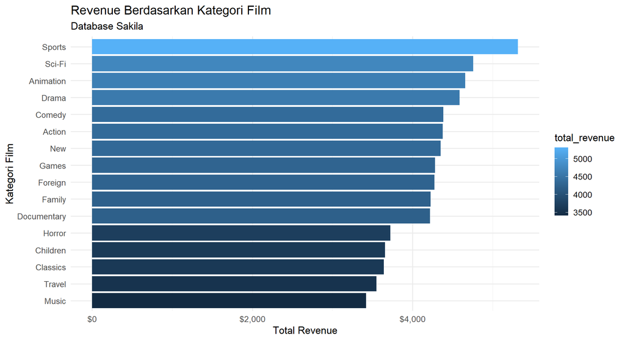

```r
revenue_category %>%
  ggplot(aes(
    x = reorder(category, total_revenue),
    y = total_revenue,
    fill = total_revenue
  )) +
  geom_col() +
  coord_flip() +
  scale_y_continuous(labels = dollar_format()) +
  labs(
    title = "Revenue Berdasarkan Kategori Film",
    subtitle = "Database Sakila",
    x = "Kategori Film",
    y = "Total Revenue"
  ) +
  theme_minimal(base_size = 13)
```

# Analisis Statistik

## Menghitung Persentase Kontribusi Revenue

```r
revenue_category <- revenue_category %>%
  mutate(
    contribution_percent =
      (total_revenue / sum(total_revenue)) * 100
  )

revenue_category %>%
  select(category, total_revenue, contribution_percent) %>%
  arrange(desc(total_revenue)) %>%
  kable(
    digits = 2,
    caption = "Kontribusi Revenue Tiap Kategori"
  ) %>%
  kable_styling(full_width = FALSE)
```

Kontribusi Revenue Tiap Kategori

| category | total_revenue | contribution_percent |
| --- | --- | --- |
| Sports | 5314.21 | 7.88 |
| Sci-Fi | 4756.98 | 7.06 |
| Animation | 4656.30 | 6.91 |
| Drama | 4587.39 | 6.81 |
| Comedy | 4383.58 | 6.50 |
| Action | 4375.85 | 6.49 |
| New | 4351.62 | 6.46 |
| Games | 4281.33 | 6.35 |
| Foreign | 4270.67 | 6.34 |
| Family | 4226.07 | 6.27 |
| Documentary | 4217.52 | 6.26 |
| Horror | 3722.54 | 5.52 |
| Children | 3655.55 | 5.42 |
| Classics | 3639.59 | 5.40 |
| Travel | 3549.64 | 5.27 |
| Music | 3417.72 | 5.07 |

# Persamaan Matematis (LaTeX)

Total revenue dihitung menggunakan persamaan berikut:

$$Revenue = \sum_{i=1}^{n} Payment_i$$

Sedangkan persentase kontribusi revenue dihitung dengan:

$$Contribution\ Percentage =
\frac{Revenue\ Category}{Total\ Revenue}
\times 100%$$

Rata-rata pembayaran:

$$Average\ Payment =
\frac{\sum Payment}{n}$$

# Interpretasi Hasil

## 1. Kategori dengan Revenue Tertinggi

Berdasarkan hasil visualisasi dan tabel revenue, kategori film dengan revenue tertinggi menunjukkan bahwa kategori tersebut memiliki permintaan paling tinggi dibanding kategori lainnya.

Kategori dengan revenue besar dapat disebabkan oleh:

- Jumlah film pada kategori tersebut lebih banyak.
- Tingkat peminjaman lebih tinggi.
- Frekuensi transaksi pelanggan yang tinggi.
- Popularitas genre tertentu.

## 2. Distribusi Revenue

Grafik menunjukkan adanya perbedaan revenue antar kategori film. Beberapa kategori memiliki kontribusi revenue yang jauh lebih besar dibanding kategori lain.

Hal ini mengindikasikan bahwa preferensi pelanggan tidak merata pada seluruh kategori film.

## 3. Insight Bisnis

Beberapa insight yang dapat diperoleh:

### a. Fokus Promosi

Perusahaan dapat memprioritaskan promosi pada kategori dengan revenue tinggi untuk meningkatkan profit.

### b. Manajemen Inventori

Kategori dengan performa tinggi dapat ditambah jumlah inventori filmnya agar mampu memenuhi permintaan pelanggan.

### c. Strategi Bundling

Kategori dengan revenue rendah dapat dipadukan dengan kategori populer melalui promo bundling.

### d. Pengambilan Keputusan

Data revenue membantu manajemen menentukan strategi bisnis berbasis data (data-driven decision making).

# Analisis Tambahan

## Top 5 Kategori Film

```r
top5 <- revenue_category %>%
  arrange(desc(total_revenue)) %>%
  head(5)

kable(
  top5,
  digits = 2,
  caption = "Top 5 Revenue Kategori Film"
) %>%
  kable_styling(full_width = FALSE)
```

Top 5 Revenue Kategori Film

| category | total_transaction | total_revenue | avg_payment | contribution_percent |
| --- | --- | --- | --- | --- |
| Sports | 1179 | 5314.21 | 4.51 | 7.88 |
| Sci-Fi | 1101 | 4756.98 | 4.32 | 7.06 |
| Animation | 1166 | 4656.30 | 3.99 | 6.91 |
| Drama | 1060 | 4587.39 | 4.33 | 6.81 |
| Comedy | 941 | 4383.58 | 4.66 | 6.50 |

# Visualisasi Top 5 Kategori

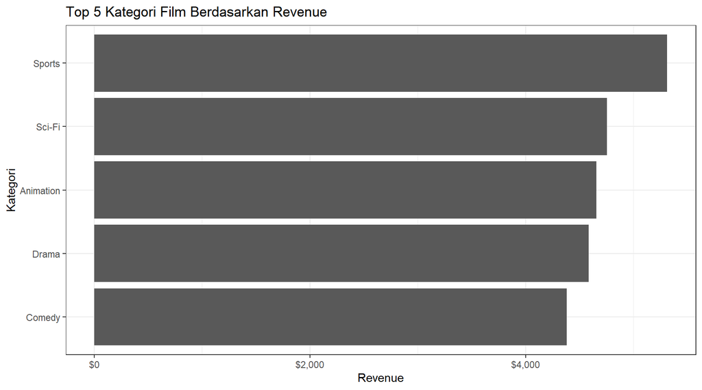

```r
revenue_category %>%
  arrange(desc(total_revenue)) %>%
  head(5) %>%
  ggplot(aes(
    x = reorder(category, total_revenue),
    y = total_revenue
  )) +
  geom_col() +
  coord_flip() +
  scale_y_continuous(labels = dollar_format()) +
  labs(
    title = "Top 5 Kategori Film Berdasarkan Revenue",
    x = "Kategori",
    y = "Revenue"
  ) +
  theme_bw()
```

# Kesimpulan

Berdasarkan analisis database Sakila, dapat disimpulkan bahwa:

1. Revenue tiap kategori film memiliki perbedaan yang cukup signifikan.
2. Kategori dengan revenue tertinggi menjadi kategori paling potensial dalam menghasilkan keuntungan.
3. Analisis data menggunakan SQL dan R dapat membantu perusahaan memahami pola bisnis secara lebih efektif.
4. Visualisasi data mempermudah interpretasi hasil dan pengambilan keputusan.

Dengan memanfaatkan data transaksi rental, perusahaan dapat mengembangkan strategi bisnis yang lebih tepat sasaran.

# Penutup

Laporan ini dibuat menggunakan:

- RMarkdown
- SQL MySQL
- ggplot2
- CSS customization
- Persamaan LaTeX

Sebagai implementasi analisis data dan visualisasi pada mata kuliah Sistem Informasi Manajemen.

# Menutup Koneksi Database

```r
dbDisconnect(con)
```